# Primer of Ecology with R: chapter 1 problems

Molly, Jacob, Mireia, Erin, Casey

```r
knitr::opts_chunk$set(fig.width = 6, fig.height = 4, # fig.path = 'Figs/lumpsucker',
                      echo = TRUE, message = FALSE, warning = FALSE)

library(tidyverse)
library(RColorBrewer)
library(primer) # install.packages('primer')
```

# Chapter 1: Problems

## 1.1. Geometric growth

Analyze the following data, relying on selected snippets of previous code.

### 1.1a

In the years 1996 through 2005, lily population sizes are N = 150, 100, 125, 200, 225, 150, 100, 175, 100, 150. Make a graph of population size versus time.

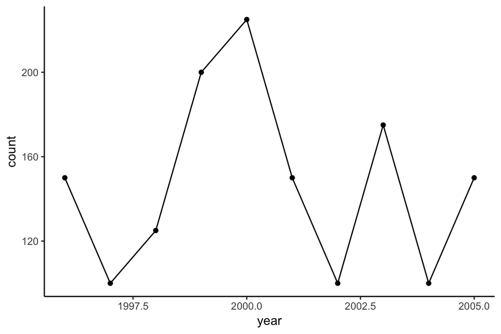

```r
### molly
lily_df <- data.frame(year = 1996:2005, count = c(150, 100, 125, 200, 225, 150, 100, 175, 100, 150))
ggplot(lily_df, aes(x = year, y = count)) +
  theme_classic() +
  geom_point() +
  geom_line()
```

### 1.1b

Calculate R for each year; graph R vs. time.

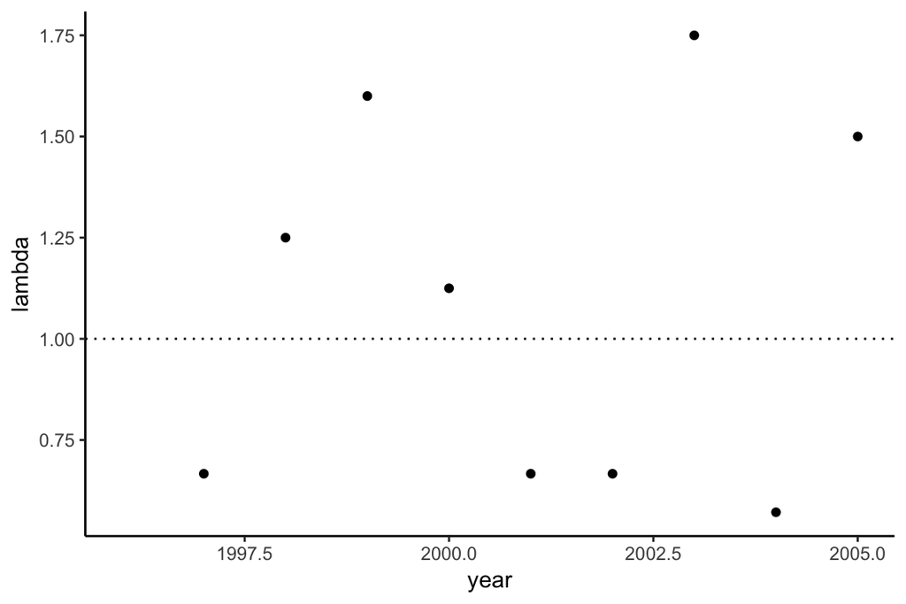

```r
### molly
lily_df <- lily_df %>%
  mutate(lambda = count / lag(count))

ggplot(lily_df, aes(x = year, y = lambda)) +
  theme_classic() +
  geom_point() +
  geom_hline(yintercept = 1, linetype = 'dotted')
```

### 1.1c

Calculate arithmetic and geometric average growth rates of this population.

```r
### molly
lily_means <- lily_df %>%
  na.omit() %>%
  summarize(lambda_a = sum(lambda) / n(),
            lambda_g = prod(lambda) ^ (1/n())
    ) ### not sure how to keep from rounding value, unless lambda_g is really that close to 1...?
```

### 1.1d

Based on the appropriate average growth rate, what would be the expected population size in 2025? What would the estimated population size be if you used the inappropriate mean? Do not use simulation for this.

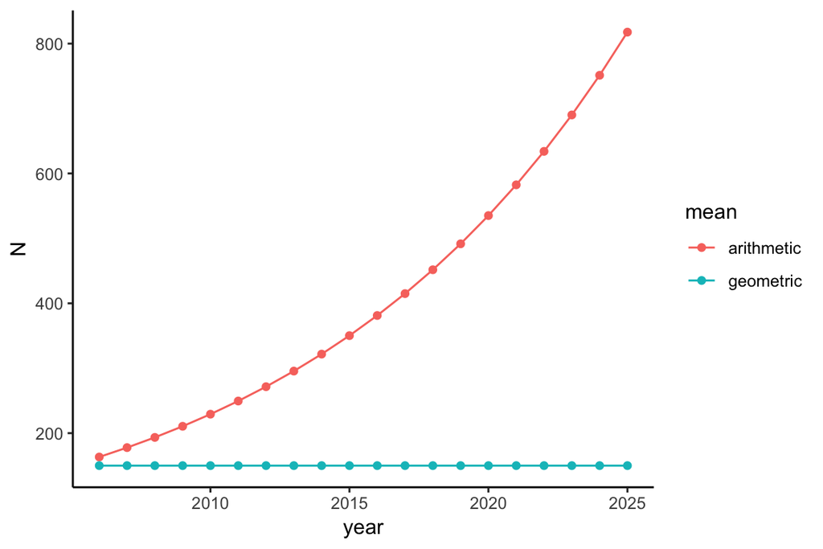

```r
### molly

### assuming we are using a deterministic model then?
N_0 = 150 ### count in 2005
t = 20
N_20_g <- N_0 * (lily_means$lambda_g)^t
N_20_a <- N_0 * (lily_means$lambda_a)^t

lily_df_proj <- data.frame(year = 2006:2025, t = 1:20, N_0 = 150) %>%
  mutate(geometric = N_0 * (lily_means$lambda_g)^t,
         arithmetic = N_0 * (lily_means$lambda_a)^t
  ) %>%
  gather(mean, N, arithmetic, geometric)

ggplot(lily_df_proj, aes(x = year, y = N, group = mean)) +
  geom_point(aes(color = mean)) +
  geom_line(aes(color = mean)) +
  theme_classic()
```

> Casey comment: from a conceptual standpoint: I think the “appropriate” mean is the geometric in general; for r = 1, then the (deterministic) population is constant, which is what we see in Molly’s graph. Based on 1.1a, it is hardly conclusive that the population is changing over time in either direction…

###1.1.d*

Given these data, develop simulations as above with the user-defined function, PopSim. Describe the distribution of projected population sizes for 2010.

```r
### molly - PopSim version first, then will try and tidy-fy...?

obs_r <- as.vector(na.omit(lily_df[,3])) ### establishing vector of observed r values

PopSim <- function(rs, N0, years, sims) {
  sim.rm = matrix(sample(rs, size = sims * years, replace = TRUE),
                  nrow = years, ncol = sims) ### creating matrix with randomly sampled rs for each year and simulation number
  output <- numeric(years + 1) ### creating blank vector with the length of all total years
  output[1] <- N0 ### seed with first value
  outmat <- sapply(1:sims, function(i) {
    for (t in 1:years) output[t + 1] <- round(output[t] * sim.rm[t, i], 0)
    output
  })
  return(outmat)
}

output <- PopSim(rs = obs_r, N0 = 150, years = 50, sims = 1000)
N.2010 <- output[15,] ### N0 is 2005
summary(N.2010, digits = 6)
```

```
##     Min.  1st Qu.   Median     Mean  3rd Qu.     Max.
##     1.00    50.75   161.00   506.92   516.50 13656.00
```

```r
    # Min.  1st Qu.   Median     Mean  3rd Qu.     Max.
    # 1.00    51.75   154.00   613.87   503.75 30172.00


### trying to tidyfy...?  Not fully there yet (adapted from Casey's code from chapter)
### first write function for single population simulation

ps_single <- function(rs, N0, years) {
  r_random <- sample(rs, size = years, replace = T) ### sample r randomly from observed values
  pop_sim <- vector('numeric', length = years + 1) ### create empty vector to store simulated populations
  pop_sim[1] <- N0 ### population in year 0
  for (yr in 1:years) {
    pop_sim[yr + 1] <- round(pop_sim[yr] * r_random[yr])
  }
}

ps_multi <- function(rs, N0, years, sims) {
  sim_list <- lapply(1:sims, FUN = function(x) {
    ps_single(rs = rs, N0 = N0, years = years)
  })
  sim_matrix <- matrix(unlist(sim_list), nrow = years + 1, ncol = sims)
}

# pop_output <- ps_multi(rs = obs_r, N0 = 150, years = 50, sims = 10)
# ### error data type...
# N.2010_tidy <- pop_output[15,]
#
# ggplot(pop_output, aes(x = yr, y = ))
```

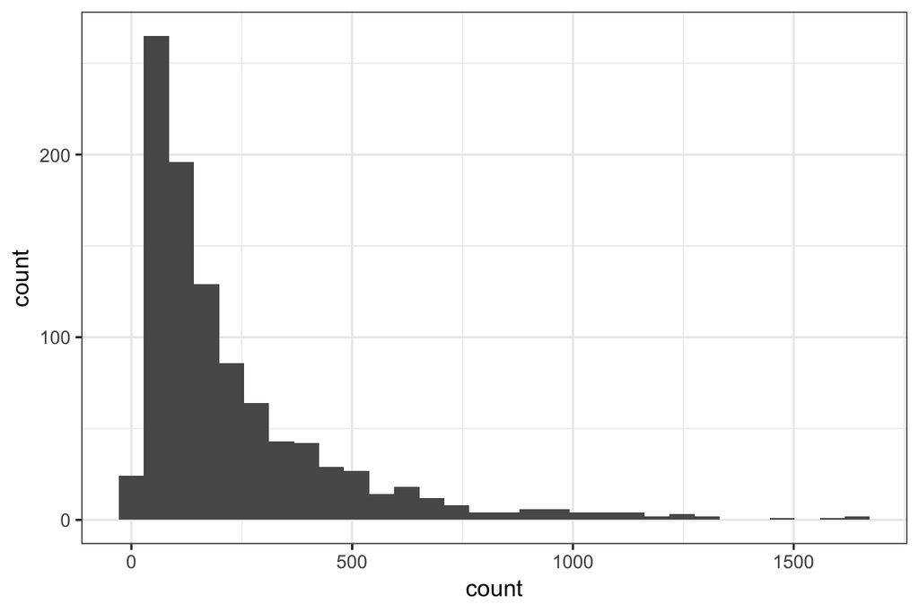

```r
### Casey's attempt

sim_pop_single <- function(n_0, n_years, l_vec) {
  count_vec <- vector(length = n_years + 1)
  count_vec[1] <- n_0
  l_sims <- sample(l_vec, size = n_years, replace = TRUE)

  for(i in 1:n_years) {
    ### project the following year's pop based on this year's pop and lambda.
    ### Note, fudging a little since lambda is defined as this year's count
    ### div by last year's count, here I'm using it more like next year's
    ### count div by this year's count...
    count_vec[i + 1] <- round(count_vec[i] * l_sims[i])
  }
  ### return whole shebang as a dataframe
  df <- data.frame(year = 0:n_years,
                   count = count_vec,
                   lambda = c(NA, l_sims))
                     ### why the NA? b/c lambda(t = 0) is NA

  return(df)
}

### copied from Molly and adapted:
lily_df <- data.frame(year = 1996:2005,
                      count = c(150, 100, 125, 200, 225, 150, 100, 175, 100, 150)) %>%
  mutate(lambda = count / lag(count))

lambda_vec <- lily_df$lambda %>%
  .[!is.na(.)] ### drop the NA

n_0 <- last(lily_df$count)
year_0 <- last(lily_df$year)
year_final <- 2010
n_years <- year_final - year_0
sims <- 1000

x <- lapply(1:sims, FUN = function(x) {
  y <- sim_pop_single(n_0 = n_0, n_years = n_years, l_vec = lambda_vec) %>%
    mutate(sim = x)
})

sims_df <- bind_rows(x)

pop_final_year <- sims_df %>%
  filter(year == max(year))

ggplot(pop_final_year, aes(x = count)) +
  theme_bw() +
  geom_histogram()
```

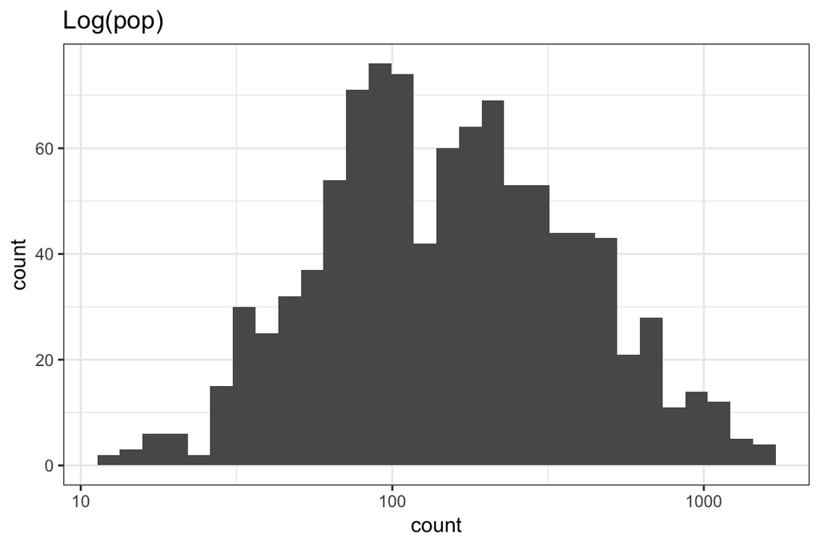

```r
ggplot(pop_final_year, aes(x = count)) +
  theme_bw() +
  geom_histogram() +
  scale_x_log10() +
  labs(title = 'Log(pop)')
```

> Casey’s comment: interesting that since the lowest $\lambda$ is 0.57 (> 0.5) and each year’s pop is rounded to the nearest integer (organism), the population can never go extinct. However, since the highest $\lambda$ is > 1.5, the pop can drop to 1 then recover to higher populations.

## 1.2. Doubling Time

###1.2a Derive the formula for doubling time in a population with continuous exponential growth.

```r
### molly

# N_t = N_0 * e^rt
# N_t = 2*N_0
# 2 = e^rt
# ln(2) = r*t*ln(e)
# t = ln(2)/r
```

#### Casey:

$$\begin{align*}
& N_t = N_0 e^{rt}\\
& N_t = aN_0\\
\Rightarrow & aN_0 = N_0 e^{rt}\\
\Rightarrow & a = e^{rt}\\
\Rightarrow & \ln a = rt\\
\Rightarrow & t_{ax} = \frac{\ln a}{r}
\end{align*}$$

For doubling time, let $a = 2$ so $t_{2x} = \frac{\ln 2}{r}$. For tripling time, $t_{3x} = \frac{\ln 3}{r}$

###1.2b

What is the formula for tripling time?

```r
### molly

# t = ln(3)/r
```

```r
### Casey creating a generic function:
doub_time <- function(r, x = 2) {
  if(length(x) > 1 & length(r) > 1) {
    ### both are vectors!  calculate all combos and return dataframe
    df <- tidyr::crossing(x, r) %>%
      mutate(t_double = log(x) / r)
    return(df)
  } else {
    ### just numbers or one vector, calculate and return a vector
    t_double <- log(x) / r
    return(t_double)
  }
}

doub_time(r = 1.2, x = c(2, 3, 4)) ### 4x time should be 2 x 2x time
```

```
## [1] 0.5776227 0.9155102 1.1552453
```

```r
doub_time(r = c(1.1, 1.3, 1.5), x = c(2, 3, 4))
```

```
## # A tibble: 9 x 3
##       x     r t_double
##   <dbl> <dbl>    <dbl>
## 1     2   1.1    0.630
## 2     2   1.3    0.533
## 3     2   1.5    0.462
## 4     3   1.1    0.999
## 5     3   1.3    0.845
## 6     3   1.5    0.732
## 7     4   1.1    1.26
## 8     4   1.3    1.07
## 9     4   1.5    0.924
```

###1.2c

If we are modeling humans or E. coli, would a model of geometric, or exponential growth be better? Why?

```r
### molly

# Geometric ($lambda$) for human populations because they reproduce in discrete time steps, and exponential ($r$) for E. coli because they reproduce continuously
```

> Casey: I’d say both would be exponential, if we’re talking the global population of humans (or some very large population) since on that scale human babies are being born essentially continuously. Perhaps for a small population it would be more like geometric? though the time intervals are not discrete per se, which seems to be a common definition of geometric growth - human babies are not limited to specific times of the year, like many other types of organisms with specific mating seasons.

###1.2d

If an E. coli population grew from $1000$ cells to $2 × 10^9$ cells in 6 h, what would its intrinsic rate of increase be? Its doubling time?

```r
### molly

N0 = 1000
N6 = 2*10^9
t = 6

### formulas:
### Nt = N0*e^(r*t)
### ln(Nt/N0) = r*t*ln(e)

r <- log(N6/N0)/t
t_doubling_hr <- log(2)/r ### in hours - so about...
t_doubling_min <- t_doubling_hr*60 ### ~ 17 min?
```

```r
### Casey using function above and a new function

calc_r <- function(n_0, n_f, t) {
  if(length(n_0) > 1 | length(n_f) > 1 | length(t) > 1) {
    stop('Initial and final pops and time must be length 1')
  }
  r <- log(n_f / n_0) / t
}

r1 <- calc_r(n_0 = 1000, n_f = 2e9, t = 6)

doub_hr <- doub_time(r1, 2)

doub_hr * 60
```

```
## [1] 17.1989
```

## 1.3. Human Population Growth

###1.3a

There were about 630 million people on the planet in 1700, and 6.3 billion in 2003 [33]. What was the intrinsic rate of increase, r?

```r
### molly

N0 = 630000000
N303 = 6300000000
t = 303

r_humans <- log(N303/N0)/(303)

### Casey's from function above:
r_hum <- calc_r(n_0 = 6.3e8, n_f = 6.3e9, t = (2003 - 1700))
```

###1.3b

Graph the model of human population size population size from 1700 to 2020.

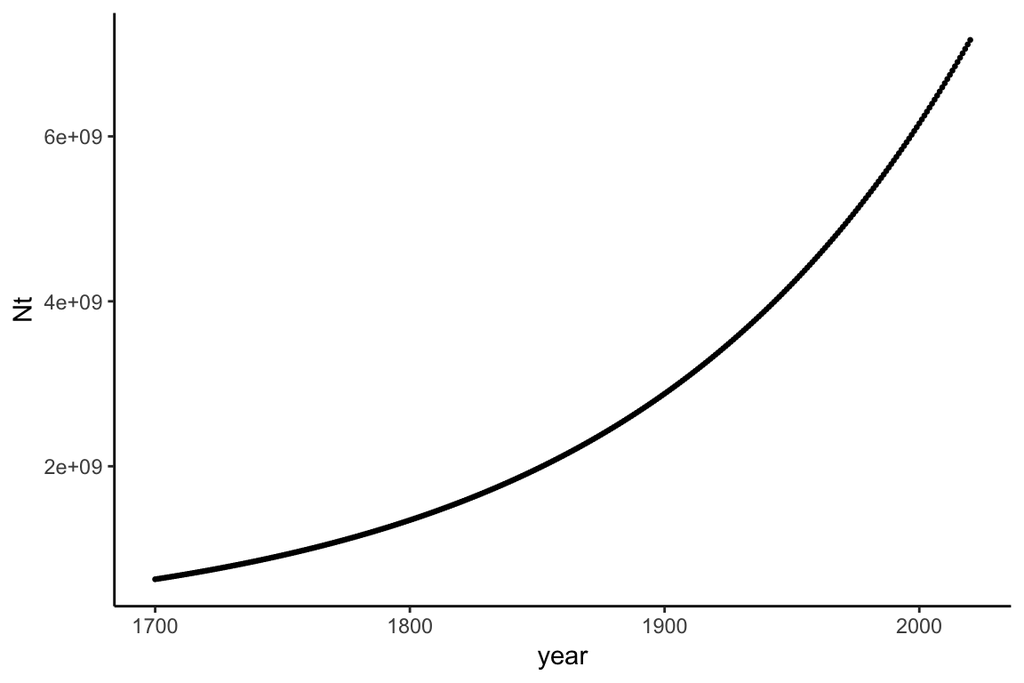

```r
### molly

humans <- data.frame(year = 1700:2020, t = 0:320, r = r_humans, N0 = 630000000) %>%
  mutate(Nt = N0 * exp(1)^(r*t))

ggplot(humans, aes(x = year, y = Nt)) +
  geom_point(size = .5) +
  theme_classic()
```

###1.3c

Add points on the graph indicating the population doublings from 1700 onward.

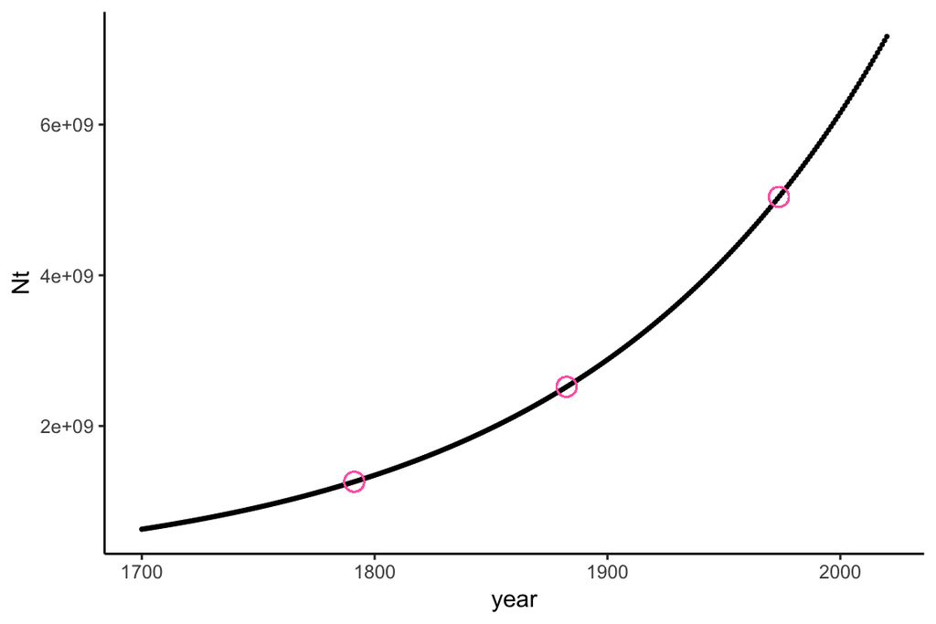

```r
### molly

t_x2 <- log(2)/r_humans
t_x4 <- log(4)/r_humans
t_x8 <- log(8)/r_humans

ggplot(humans, aes(x = year, y = Nt)) +
  geom_point(size = .5) +
  geom_point(aes(x = t_x2 + 1700, y = N0 * exp(1)^(r_humans*t_x2)), shape = 1, size = 4, colour = "hotpink") +
  geom_point(aes(x = t_x4 + 1700, y = N0 * exp(1)^(r_humans*t_x4)), shape = 1, size = 4, colour = "hotpink") +
  geom_point(aes(x = t_x8 + 1700, y = N0 * exp(1)^(r_humans*t_x8)), shape = 1, size = 4, colour = "hotpink") +
  theme_classic()
```

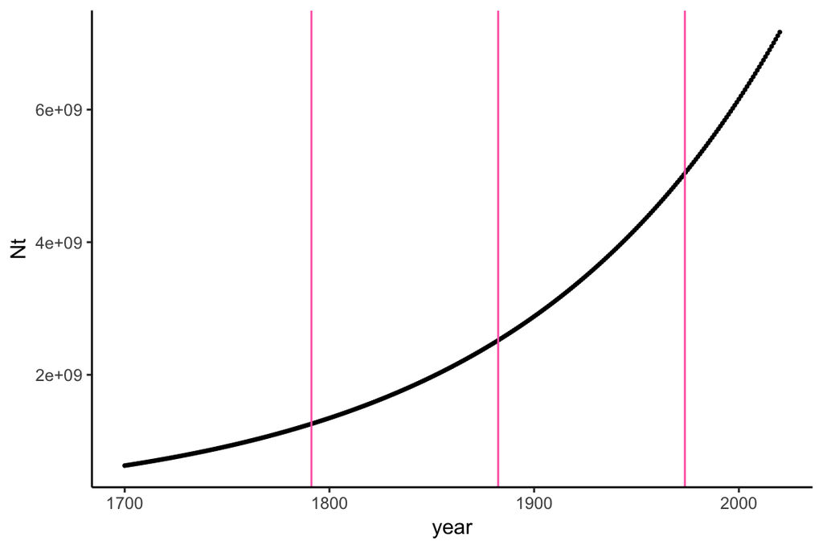

```r
### Casey's version, starting from Molly's - using vline for doublings

pop_double_vec <- c(2, 4, 8)
t_double_vec <- log(pop_double_vec) / r_humans + 1700

ggplot(humans, aes(x = year, y = Nt)) +
  geom_point(size = .5) +
  geom_vline(xintercept = t_double_vec, colour = "hotpink") +
  theme_classic()
```

###1.3d What will prevent humans from outweighing the planet by the end of this century? What controls human population growth? Do these controls vary spatially across the planet? See Cohen [33] to get going.

## 1.4. R functions

Find the R functions in Chapter 1. Demonstrate their uses.